# **“Analyzing RNA-Seq of model media and MRS strains with DESeq2”**

*date*: “4/27/2023”

*output*: html_document, png images

*overview*: Dataset in this file includes isolates grown in three model media: Pineapple Juice extract, Drosophila melanogaster extract and A. mellifera L. worker bee extract. It also includes the MRS medium in which one chosen isolated from each extract was grown. Differential gene expression analysis for PCA construction done by using MRS as relevel. The GEO accession numbers for these dataset are:

| Geo Accession | Identification |
| --- | --- |
| GSM3178354 | BEE1ST |
| GSM3178355 | BEE2ST |
| GSM3178356 | BEE3ST |
| GSM3178357 | DE12 |
| GSM3178358 | DE12II |
| GSM3178359 | DE24 |
| GSM3178376 | PJ16 |
| GSM3178377 | PJ20 |
| GSM3178378 | PJ1 |
| GSM3178389 | BEE1ST_MRS |
| GSM3178383 | DE12_MRS |
| GSM3178388 | PJ16_MRS |

**This file also continues** to explore the data set to visualize it in **volcano plots, boxplots, and heatmaps.** The analysis helps highlight the regulation of the transcriptome when strains are switched from model medias to corresponding MRS media. Overall limitations for this DEG analysis revolved around annotation of the reference file not including specific gene ids that could be sourced in BacteriaEnsembl and also a limitation in the experimental design itself where only one MRS strain was grown for each three corresponding model media strains, thus skewing visualization of some plots (hence I assume why they were not included in the paper).

Citation: Filannino, P., De Angelis, M., Di Cagno, R., Gozzi, G., Riciputi, Y., & Gobbetti, M. (2018). How Lactobacillus plantarum shapes its transcriptome in response to contrasting habitats. Environmental microbiology, 20(10), 3700–3716. https://doi.org/10.1111/1462-2920.14372

#### Install the required R libraries

```r
#Install CRAN packages
install.packages(c("knitr", "RColorBrewer", "pheatmap"))
```

#### Load the required libraries

```r
library(knitr)
library(DESeq2)
```

```r
library(RColorBrewer)
library(pheatmap)
library(ggplot2)
library(tidyverse)
library(EnhancedVolcano)
library(biomaRt)
library(dplyr)
library(tidyr)
library(cowplot)
```

1. **Generate sample table**

   To start the analysis, a sample table with references is needed.

```r
sampleTable <- read.csv("Annotation.csv", header = T)
```

```r
#Convert to data frame
sampleTable <- data.frame(sampleTable)
```

2. Create factors for **condition, batch, replicate, and color.**

```r
#specify as factor
condition <- factor(sampleTable$condition)
replicate <- factor(sampleTable$replicate)
batch <- factor(sampleTable$batch)
color <- factor(sampleTable$color)
```

3. **Run DESeq2 with condition set as design.** The sampleTable in this case is built from the annotation file that contains both medel media and MRS. Only condition is included in the design because were only comparing media strains to corresponding MRS strain. These files can be found in the same directory which is why “.” is specified.

```r
dds <- DESeqDataSetFromHTSeqCount(sampleTable = sampleTable,
                                  directory = ".",
                                  design = ~ condition)
dds
```

```
## class: DESeqDataSet
## dim: 3174 12
## metadata(1): version
## assays(1): counts
## rownames(3174): LP_RS00005 LP_RS00010 ... LP_RS16120 LP_RS16125
## rowData names(0):
## colnames(12): GSM3178354 GSM3178355 ... GSM3178378 GSM3178388
## colData names(4): condition replicate batch color
```

4. Pre-filtering to discard any counts of **less than 10.**

```r
keep <- rowSums(counts(dds)) >= 10
dds <- dds[keep,]
```

5. Set the three different MRS grown strains as controls for each growing condition.

```r
dds$condition <- relevel(dds$condition, ref = "MRS1","MRS2","MRS3")
```

6. **Run differential analysis.**

   Three contrasts are created because there are three conditions being avaluated in reference to three controls (with one replicate per control). It wouldnt make sense to contrast model media to an MRS control that doesnt correpond to that model media, so three different groups were created.

```r
dds <- DESeq(dds)
res1 <- results(dds, (contrast=c('condition','Model_Media1','MRS1')))
res2 <- results(dds,(contrast=c('condition','Model_Media2','MRS2')))
res3 <- results(dds,(contrast=c('condition','Model_Media3','MRS3')))


#ordering results table by the smallest *padj* value:
result1 <- res1[order(res1$padj), ]
result2 <- res2[order(res2$padj), ]
result3 <- res3[order(res3$padj), ]


write.csv(res1,"BeevsMRS1.csv")
write.csv(res2,"DrosphilavsMRS2.csv")
write.csv(res3,"PinapplevsMRS3.csv")
```

7. p-values were adjusted with **Benjamini-Hochberg’s FDR correction**

```r
table(result1$padj<0.05)
```

```
##
## FALSE  TRUE
##  2505   378
```

```r
table(result2$padj<0.05)
```

```
##
## FALSE  TRUE
##  2154   729
```

```r
table(result3$padj<0.05)
```

```
##
## FALSE  TRUE
##  2440   385
```

8. Merge all three different results with normalized data.

```r
resdata1 <- merge(as.data.frame(result1), as.data.frame(counts(dds, normalized=TRUE)), by="row.names", sort=FALSE)
names(resdata1)[1] <- "Gene_id"
resdata2 <- merge(as.data.frame(result2), as.data.frame(counts(dds, normalized=TRUE)), by="row.names", sort=FALSE)
names(resdata2)[1] <- "Gene_id"
resdata3 <- merge(as.data.frame(result3), as.data.frame(counts(dds, normalized=TRUE)), by="row.names", sort=FALSE)
names(resdata3)[1] <- "Gene_id"



#write results into csv files
write.csv(resdata1, file="Model1vsMRS1_unfiltered_matrix.csv")
write.csv(resdata2, file="Model2vsMRS2_unfiltered_matrix.csv")
write.csv(resdata3, file="Model3vsMRS3_unfiltered_matrix.csv")
```

The authors of the paper set the criteria of a transcript being identified as significantly differentially expressed if it had fold change **≥ 2 (or ≤ -2) and FDR q-value ≤ 0.1**. Filtering will be done to reflect this.

```r
#Get DEG up/down lists
resdata1 <- as.data.frame(result1) %>% dplyr::filter(abs(log2FoldChange) >= 2 & padj <= 0.1) %>% tibble::rownames_to_column("Gene_id")
resdata2 <- as.data.frame(result2) %>% dplyr::filter(abs(log2FoldChange) >= 2 & padj <= 0.1) %>% tibble::rownames_to_column("Gene_id")
resdata3 <- as.data.frame(result3) %>% dplyr::filter(abs(log2FoldChange) >= 2 & padj <= 0.1) %>% tibble::rownames_to_column("Gene_id")

#write results
write.csv(resdata1, "Model1vsMRS1_log2fc2_fdr01_DEGlist.csv", row.names = TRUE)
write.csv(resdata2, "Model2vsMRS2_log2fc2_fdr01_DEGlist.csv", row.names = TRUE)
write.csv(resdata3, "Model3vsMRS3_log2fc2_fdr01_DEGlist.csv", row.names = TRUE)
```

## Data transformation and visualization

### Principal components analysis (PCA)

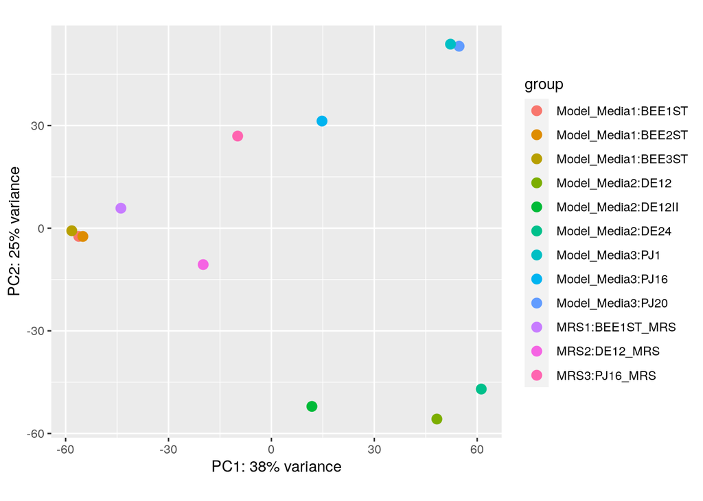

```r
vstcounts <- rlog(dds, blind=FALSE)
plotPCA(vstcounts, intgroup=c("condition","batch"))
```

2. **Customize the *ggplot* to show each condition**: pineapple juice, drosphilia extract, or bee extract. Set all the MRS as one different condition to highlight as the “generalized” transcriptome its supposed to have.

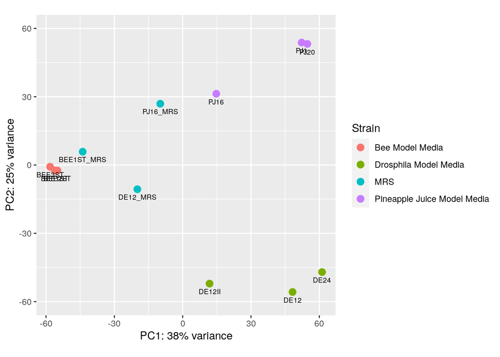

```r
#Correct some more formattin for labels and making sure the x and y axis are similar using `ylim` argument.
pcaData <- plotPCA(vstcounts, intgroup=c("condition", "batch"), returnData=TRUE)
percentVar <- round(100 * attr(pcaData, "percentVar"))
ggplot(pcaData, aes(PC1, PC2, color=color)) +
  scale_colour_discrete(name="Strain")+
  geom_point(size=3) +
  geom_text(label=batch, color = 'black', size=2.5, position = position_nudge(y = -3.5))+
  ylim(-60,60) +
  xlab(paste0("PC1: ",percentVar[1],"% variance")) +
  ylab(paste0("PC2: ",percentVar[2],"% variance")) +

  coord_fixed()
```

```r
# Save the PCA plot
ggsave(path = "Figs", filename = "PCA2.png",  height=5, width=6, units='in', dpi = 300, bg = "transparent", device='png')
```

3. Generating **correlation heatmap**, this is not an included figure of the paper but its nice to see that transcripts originating in the same media have higher correlation. It also helps highlight how some of the isolates, while not grown is MRS are still very generalized suggesting nomadic adaptations can also tend to generalized transcripts too.

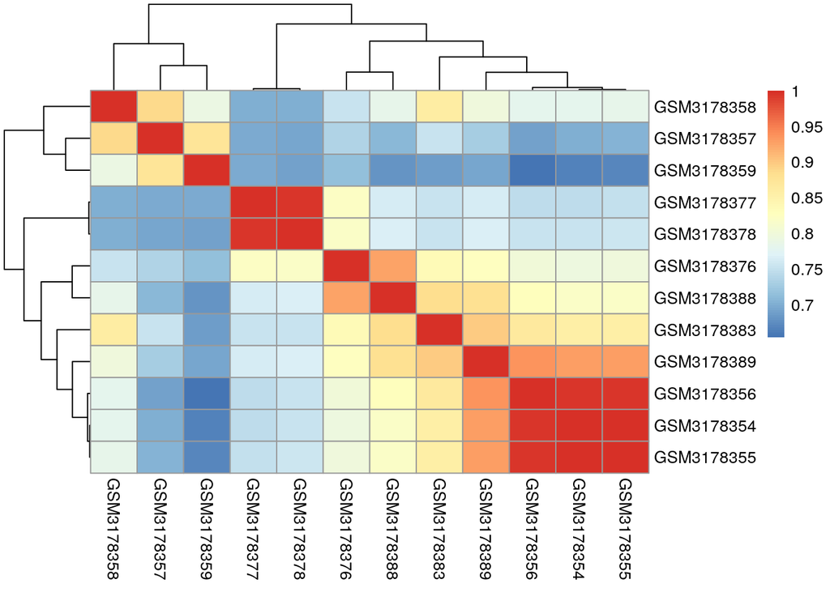

```r
library(pheatmap)
rld <- rlog(dds, blind=FALSE)
rld_mat <- assay(rld)
rld_cor <- cor(rld_mat)
pheatmap(rld_cor)
```

### Volcano Plots

**For this dataset I will continue analysis to include volcano plots to visualize the DEG between the model media and the MRS. I thought it would be more significant as it would help analyze how the strains return to a generalized transcriptome in the general nutrition media.**

#### Simple volcano plots

1. Prepping the data for volcano plot

```r
resdata1 <- read.csv("Model1vsMRS1_unfiltered_matrix.csv", header = T)
resdata1 <- resdata1[, c(2:20)]


resdata2 <- read.csv("Model2vsMRS2_unfiltered_matrix.csv", header = T)
resdata2 <- resdata2[, c(2:20)]


resdata3 <- read.csv("Model3vsMRS3_unfiltered_matrix.csv", header = T)
resdata3 <- resdata3[, c(2:20)]
```

2. Set differential expression level based on **padj**. Again, authors used a value of **0.1** to be considered as significant.

```r
threshold_padj1 <- resdata1$padj < 0.1
length(which(threshold_padj1)) ## Determine the number of TRUE values
```

```
## [1] 482
```

```r
threshold_padj2 <- resdata2$padj < 0.1
length(which(threshold_padj2)) ## Determine the number of TRUE values
```

```
## [1] 907
```

```r
threshold_padj3 <- resdata3$padj < 0.1
length(which(threshold_padj3)) ## Determine the number of TRUE values
```

```
## [1] 521
```

3. Setting **thresholds**.

```r
resdata1$threshold <- threshold_padj1 ## Add vector as a column (threshold) to the resdata


resdata2$threshold <- threshold_padj2 ## Add vector as a column (threshold) to the resdata


resdata3$threshold <- threshold_padj3 ## Add vector as a column (threshold) to the resdata
```

4. Now that threshold is set, we can visualize through ggplot.

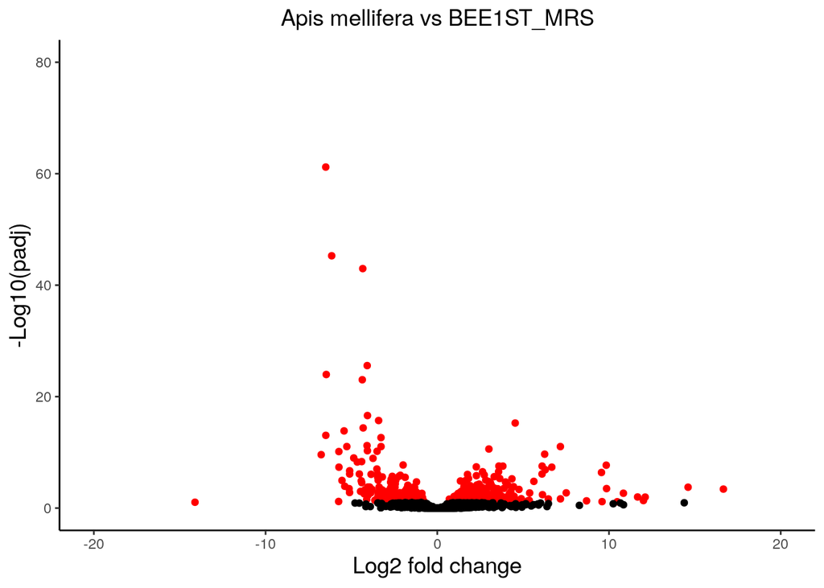

```r
ggplot(resdata1) +
        geom_point(aes(x=log2FoldChange,
                       y=-log10(padj), colour=threshold)) +
  theme_classic() +
        ggtitle("Apis mellifera vs BEE1ST_MRS") +
        xlab("Log2 fold change") +
        ylab("-Log10(padj)") +
        theme(legend.position = "none",
              plot.title = element_text(size = rel(1.25), hjust = 0.5),
              axis.title = element_text(size = rel(1.25))) +
  scale_color_manual(values = c("black", "red")) +
  scale_x_continuous(limits = c(-20, 20)) +
  coord_cartesian(ylim=c(0, 80), clip = "off")
```

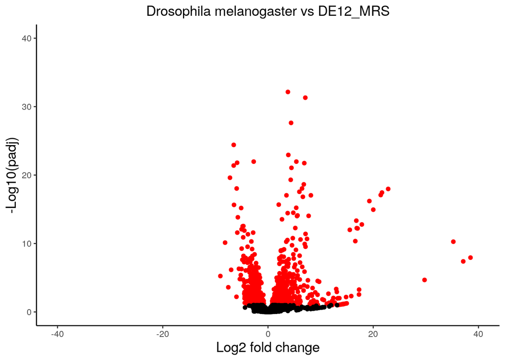

```r
ggplot(resdata2) +
        geom_point(aes(x=log2FoldChange,
                       y=-log10(padj), colour=threshold)) +
  theme_classic() +
        ggtitle("Drosophila melanogaster vs DE12_MRS") +
        xlab("Log2 fold change") +
        ylab("-Log10(padj)") +
        theme(legend.position = "none",
              plot.title = element_text(size = rel(1.25), hjust = 0.5),
              axis.title = element_text(size = rel(1.25))) +
  scale_color_manual(values = c("black", "red")) +
  scale_x_continuous(limits = c(-40, 40)) +
  coord_cartesian(ylim=c(0, 40), clip = "off")
```

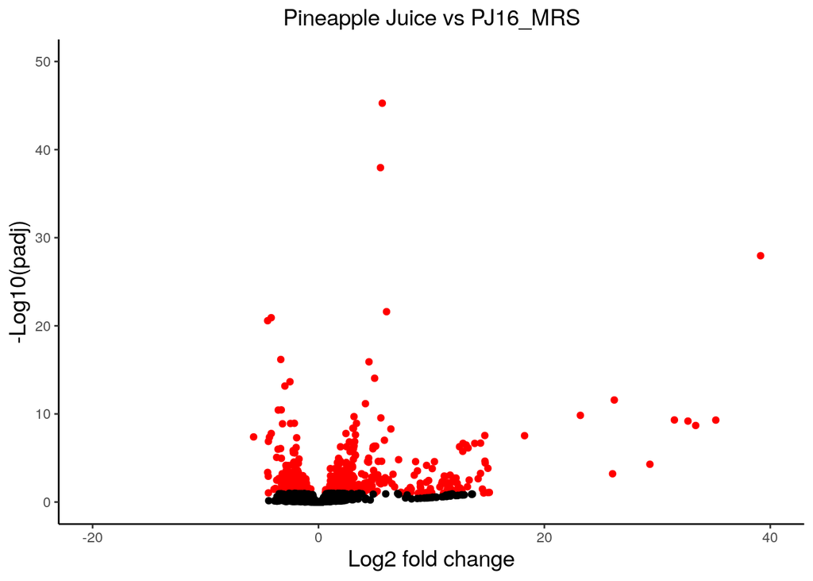

```r
ggplot(resdata3) +
        geom_point(aes(x=log2FoldChange,
                       y=-log10(padj), colour=threshold)) +
  theme_classic() +
        ggtitle("Pineapple Juice vs PJ16_MRS") +
        xlab("Log2 fold change") +
        ylab("-Log10(padj)") +
        theme(legend.position = "none",
              plot.title = element_text(size = rel(1.25), hjust = 0.5),
              axis.title = element_text(size = rel(1.25))) +
  scale_color_manual(values = c("black", "red")) +
  scale_x_continuous(limits = c(-20, 40)) +
  coord_cartesian(ylim=c(0, 50), clip = "off")
```

#### Enhanced volcano plot

While the above are good for a quick visualization of the DEG, enhanced Volcano Plots are better at creating literature quality figures. In these figures I will highlight some of the most differential expressed genes that are also involved in **energy production or de novo amino acid synthesis**.

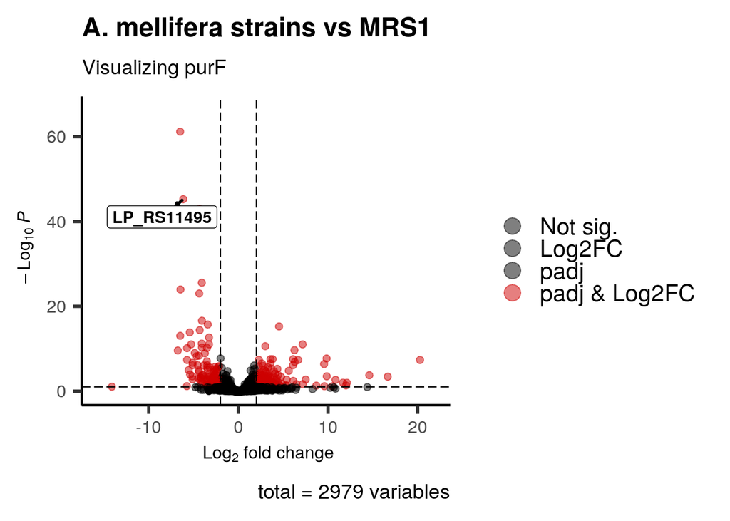

```r
EnhancedVolcano(resdata1,
                lab = as.character(resdata1$Gene_id),
                x = 'log2FoldChange',
                y = 'padj',
                selectLab = c("LP_RS11495"),
                title = "A. mellifera strains vs MRS1",
                subtitle = "Visualizing purF",
                FCcutoff = 2,
                pCutoff = 0.1,
                labSize = 4,
                axisLabSize = 12,
                col=c('black', 'black', 'black', 'red3'),
                labCol = 'black',
                labFace = 'bold',
                boxedLabels = TRUE,
                legendLabels=c('Not sig.','Log2FC','padj', 'padj & Log2FC'),
                legendPosition = 'right',
                legendLabSize = 16,
                legendIconSize = 5.0,
                drawConnectors = TRUE,
                widthConnectors = 1.0,
                colConnectors = 'black',
                gridlines.major = FALSE,
                gridlines.minor = FALSE)
```

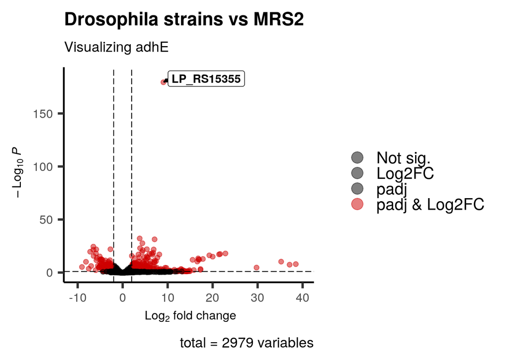

```r
ggsave(path = "Figs",filename ='Bee-volcano.png')
EnhancedVolcano(resdata2,
                lab = as.character(resdata2$Gene_id),
                x = 'log2FoldChange',
                y = 'padj',
                selectLab = c("LP_RS15355"),
                title = "Drosophila strains vs MRS2",
                subtitle = "Visualizing adhE",
                FCcutoff = 2,
                pCutoff = 0.1,
                labSize = 4,
                axisLabSize = 12,
                col=c('black', 'black', 'black', 'red3'),
                labCol = 'black',
                labFace = 'bold',
                boxedLabels = TRUE,
                legendLabels=c('Not sig.','Log2FC','padj', 'padj & Log2FC'),
                legendPosition = 'right',
                legendLabSize = 16,
                legendIconSize = 5.0,
                drawConnectors = TRUE,
                widthConnectors = 1.0,
                colConnectors = 'black',
                gridlines.major = FALSE,
                gridlines.minor = FALSE)
```

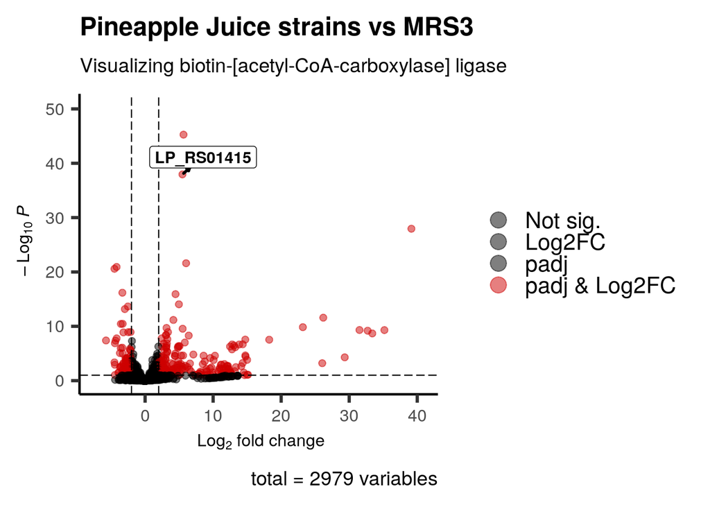

```r
ggsave(path = "Figs",filename ='Drosophila-volcano.png')
EnhancedVolcano(resdata3,
                lab = as.character(resdata3$Gene_id),
                x = 'log2FoldChange',
                y = 'padj',
                selectLab = c("LP_RS01415"),
                title = "Pineapple Juice strains vs MRS3",
                subtitle = "Visualizing biotin-[acetyl-CoA-carboxylase] ligase",
                FCcutoff = 2,
                pCutoff = 0.1,
                labSize = 4,
                axisLabSize = 12,
                col=c('black', 'black', 'black', 'red3'),
                labCol = 'black',
                labFace = 'bold',
                boxedLabels = TRUE,
                legendLabels=c('Not sig.','Log2FC','padj', 'padj & Log2FC'),
                legendPosition = 'right',
                legendLabSize = 16,
                legendIconSize = 5.0,
                drawConnectors = TRUE,
                widthConnectors = 1.0,
                colConnectors = 'black',
                gridlines.major = FALSE,
                gridlines.minor = FALSE)
```

```r
ggsave(path = "Figs",filename ='Pineapple-volcano.png')
```

### Boxplots

**To further visualize the specific DEG we can use boxplots.**

**In my opinion boxplot grids wouldnt be as useful to visualize this data because the comparison to one MRS sample for every each model media limits the possible variation. Therefore, all the MRS boxes will be seen as a line will the model media variation will not be visualized properly. However, for the sake of looking at individual gene expression, its still useful.**

1. The first step would be to create filtered csv files and top20 DEG csv file.

```r
#Top20 DEG
resdata1_sig <- as.data.frame(resdata1) %>% dplyr::filter(abs(log2FoldChange) > 2 & padj < 0.1)
write.csv(resdata1_sig, file="Model1vsMRS1_DEG.csv")

top20_Model1vsMRS1 <- resdata1_sig [c(1:20),c(1,8:11)]
write.csv(top20_Model1vsMRS1, file="top_20_DEG_Model1vsMRS1.csv")

#Contrast2
resdata2_sig <- as.data.frame(resdata2) %>% dplyr::filter(abs(log2FoldChange) > 2 & padj < 0.1)
write.csv(resdata2_sig, file="Model2vsMRS2_DEG.csv")

top20_Model2vsMRS2 <- resdata2_sig [c(1:20),c(1,12:15)]
write.csv(top20_Model2vsMRS2, file="top_20_DEG_Model2vsMRS2.csv")

#Contrast3
resdata3_sig <- as.data.frame(resdata3) %>% dplyr::filter(abs(log2FoldChange) > 2 & padj < 0.1)
write.csv(resdata3_sig, file="Model3vsMRS3_DEG.csv")

top20_Model3vsMRS3 <- resdata3_sig [c(1:20),c(1,16:19)]
write.csv(top20_Model3vsMRS3, file="top_20_DEG_Model3vsMRS3.csv")
```

2. Create top_deg objects

```r
top_deg1 <- read.csv("top_20_DEG_Model1vsMRS1.csv", header = T)
top_deg2 <- read.csv("top_20_DEG_Model2vsMRS2.csv", header = T)
top_deg3 <- read.csv("top_20_DEG_Model3vsMRS3.csv", header = T)
```

3. Create annotation file

```r
meta <- read.csv("Annotation_DEG.csv", header = T)
```

4. Create Expression Plots for each contrast.

```r
expression_plot1 <- pivot_longer(top_deg1,
                                cols = 3:6,
                                values_to = "normalized_counts1")

expression_plot2 <- pivot_longer(top_deg2,
                                cols = 3:6,
                                values_to = "normalized_counts2")

expression_plot3 <- pivot_longer(top_deg3,
                                cols = 3:6,
                                values_to = "normalized_counts3")
```

5. Join expression plot and meta table

```r
# Join metadata for visualizing groups or features for DEG 1
expression_plot1 <- left_join(x = expression_plot1,
                             y = meta,
                             by = "name")

# Join metadata for visualizing groups or features for DEG 2
expression_plot2 <- left_join(x = expression_plot2,
                             y = meta,
                             by = "name")


# Join metadata for visualizing groups or features for DEG 3
expression_plot3 <- left_join(x = expression_plot3,
                             y = meta,
                             by = "name")
```

6. Look at genes of interest. I focused on one example for each contrasts. These were picked from the top 20 DEG and clearly stood out in the volcano plots. I also decided to focus on these because they were involved in either energy sources (**AdheE and purF**) or de novo amino acid synthesis (the **Biotin-[acetyl-CoA-carboxylase] ligase**)

   a. Look at gene of interest for Bee Extract.

```r
#This would be the purF
LP_RS11495 <- expression_plot1 %>%
filter(Gene_id == "LP_RS11495")

# Plot into box chart
boxplot_purF<-ggplot(LP_RS11495) +
  geom_boxplot(aes(x=condition,
                   y=normalized_counts1,
                   fill=condition)) +
  labs(title = "purF",
              subtitle = "A. mellifera vs MRS1")+
     theme_bw() + scale_fill_manual(values = c("blue", "red")) +
        ggtitle("purF") +
        xlab("Condition") +
        ylab("Normalized Counts") +
        theme(legend.position = "right",
              plot.title = element_text(size = rel(1.25), hjust = 0.5),
              plot.subtitle = element_text(size=rel(0.7),hjust = 0.5),#subtitle
              axis.title = element_text(size = rel(0.75)),
              axis.text = element_text(size = rel(0.75))) #axis
```

b. Look at a gene of interest for Fly Extract

```r
#This would be the Acetaldehyde-alcohol dehydrogenase (AdhE gene)
LP_RS15355_exp <- expression_plot2 %>%
filter(Gene_id == "LP_RS15355")

# Plot into box chart
boxplot_AdhE<-ggplot(LP_RS15355_exp) +
  geom_boxplot(aes(x=condition,
                   y=normalized_counts2,
                   fill=condition)) +
  labs(title = "AdhE",
              subtitle = "Drosophila vs MRS2")+
     theme_bw() + scale_fill_manual(values = c("blue", "red")) +
        ggtitle("AdhE") +
        xlab("Condition") +
        ylab("Normalized Counts") +
        theme(legend.position = "right",
              plot.title = element_text(size = rel(1.25), hjust = 0.5),
              plot.subtitle = element_text(size=rel(0.7),hjust = 0.5),#subtitle
              axis.title = element_text(size = rel(0.75)),
              axis.text = element_text(size = rel(0.75))) #axis
```

c. Look at a gene of interest for Pineapple juice extract

```r
#This would be the biotin-[acetyl-CoA-carboxylase] ligase.
LP_RS01415_exp <- expression_plot3 %>%
filter(Gene_id == "LP_RS01415")

# Plot into box chart
boxplot_biotin<-ggplot(LP_RS01415_exp) +
  geom_boxplot(aes(x=condition,
                   y=normalized_counts3,
                   fill=condition)) +
     theme_bw() + scale_fill_manual(values = c("blue", "red")) +
        ggtitle("Biotin-[acetyl-CoA-carboxylase] ligase") +
    labs(title = "Biotin-[acetyl-CoA-carboxylase] ligase",
              subtitle = "Pineapple Juice vs MRS3")+
        xlab("Condition") +
        ylab("Normalized Counts") +
        theme(legend.position = "right",
              plot.title = element_text(size = rel(0.9), hjust = 0.5), #title
              plot.subtitle = element_text(size=rel(0.7),hjust = 0.5),
              axis.title = element_text(size = rel(0.75)),
              axis.text = element_text(size = rel(0.75))) #axis
```

7. Arrange into a grid for ease of visualization

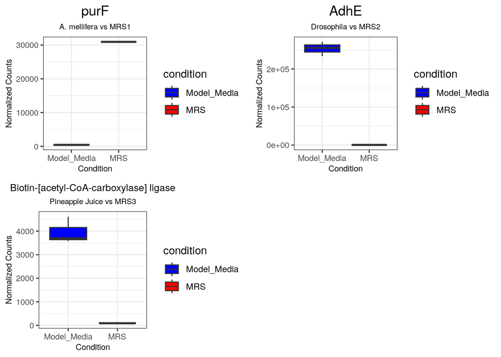

```r
# Arranging multiple plots in a figure
boxplot_grid <- plot_grid(boxplot_purF,
                          boxplot_AdhE,
                          boxplot_biotin,
                          ncol = 2)
boxplot_grid
```

```r
ggsave(path = "Figs",filename ='boxplot_grid.png')
```

### Heatmaps

**Maybe a better way to visualize the DEG in this experiment is through heat maps. As comapring the different contrasts is better than looking at differences between groups.**

1. Start by placing the normalized DEG into a heatmap file. This is repeated for each contrast.

```r
#Set conditions for Bee contrast

BeeFilteredModelvsMRS <- resdata1_sig [,c(8:11)]
write.csv(BeeFilteredModelvsMRS, file="BeeModelvsMRS_DEG.csv")


Beeheatmap_normDEG <- read.csv("BeeModelvsMRS_DEG.csv", header = T, row.names = 1)
heatmap_meta <- read.csv("BeeMap.csv", header = T)

#Set conditions for Bee contrast

FlyFilteredModelvsMRS <- resdata2_sig [,c(12:15)]
write.csv(FlyFilteredModelvsMRS, file="FlyModelvsMRS_DEG.csv")


Flyheatmap_normDEG <- read.csv("FlyModelvsMRS_DEG.csv", header = T, row.names = 1)
heatmap_meta2 <- read.csv("FlyMap.csv", header = T)

#Set conditions for Pineapple contrast

PineappleFilteredModelvsMRS <- resdata3_sig [,c(16:19)]
write.csv(PineappleFilteredModelvsMRS, file="PineappleModelvsMRS_DEG.csv")


Pineappleheatmap_normDEG <- read.csv("PineappleModelvsMRS_DEG.csv", header = T, row.names = 1)
heatmap_meta3 <- read.csv("PineappleMap.csv", header = T)
```

2. Set the conditions for each file. This includes names, reference levels, colors to indicate up or down regulation, and colors for annotation.

```r
# Assign the sample names to be the row names
rownames(heatmap_meta) <- heatmap_meta$name
rownames(heatmap_meta2) <- heatmap_meta2$name
rownames(heatmap_meta3) <- heatmap_meta3$name

# Re-level factors
heatmap_meta$condition <- factor(heatmap_meta$condition, levels = c("Bee", "MRS"))
heatmap_meta2$condition <- factor(heatmap_meta2$condition, levels = c("Drosophila", "MRS"))
heatmap_meta3$condition <- factor(heatmap_meta3$condition, levels = c("Pineapple", "MRS"))

# Colors for heatmap
heatmap_colors <- colorRampPalette(c("blue", "white", "red"))(6)


# Colors for denoting annotations
ann_colors <- list(condition = c(Bee= "#D11313", MRS= "#6DB0F8"))
ann_colors2 <- list(condition = c(Drosophila= "#D11313", MRS= "#6DB0F8"))
ann_colors3 <- list(condition = c(Pineapple= "#D11313", MRS= "#6DB0F8"))
```

3. Perform pheatmap and attribute each plot to an object.

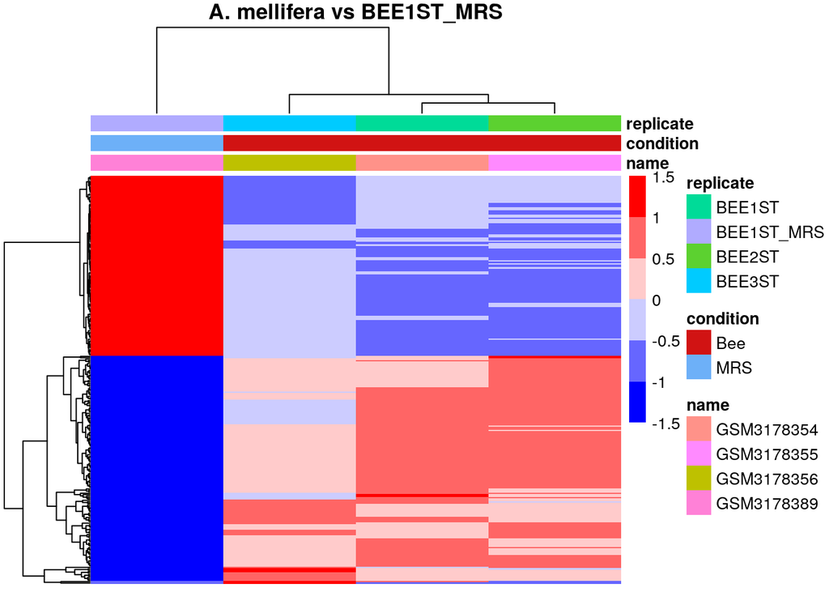

```r
bee<-pheatmap(Beeheatmap_normDEG,
         color = heatmap_colors,
         annotation_col = heatmap_meta,
         annotation_colors = ann_colors,
         show_colnames = F,
         show_rownames = F,
         main = ('A. mellifera vs BEE1ST_MRS'),
         scale = "row")
```

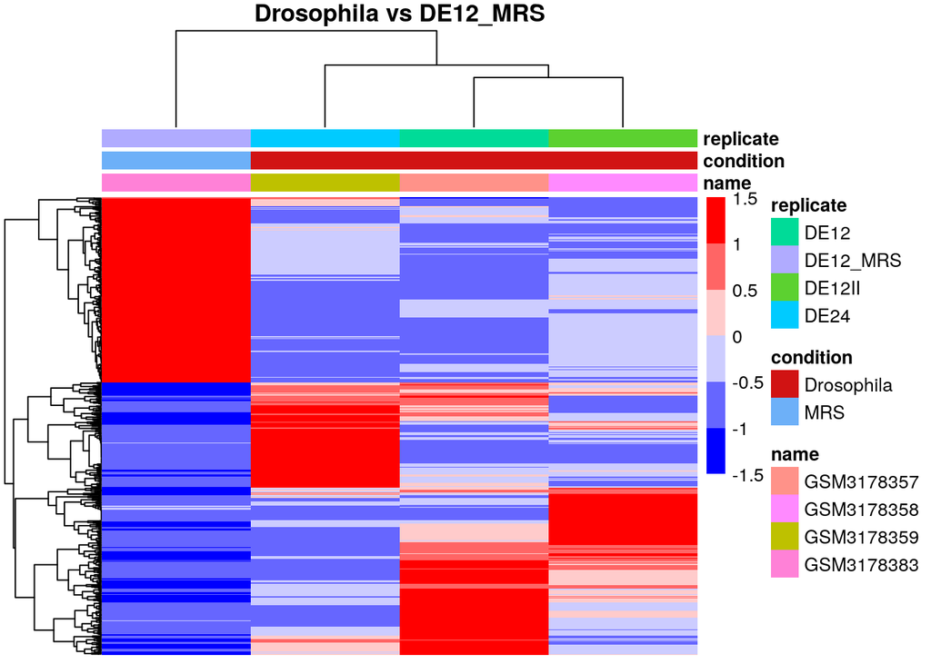

```r
drosophila<-pheatmap(Flyheatmap_normDEG,
         color = heatmap_colors,
         annotation_col = heatmap_meta2,
         annotation_colors = ann_colors2,
         show_colnames = F,
         show_rownames = F,
        main = ('Drosophila vs DE12_MRS'),
         scale = "row")
```

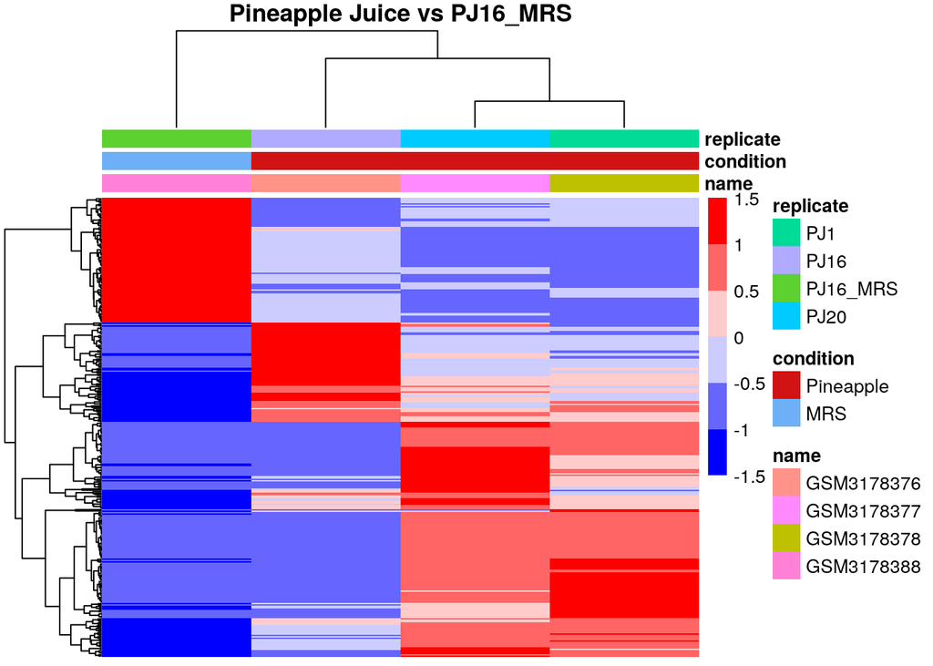

```r
pineapple<-pheatmap(Pineappleheatmap_normDEG,
         color = heatmap_colors,
         annotation_col = heatmap_meta3,
         annotation_colors = ann_colors3,
         show_colnames = F,
         show_rownames = F,
         main = ('Pineapple Juice vs PJ16_MRS'),
         scale = "row")
```

```r
save_pheatmap_pdf <- function(x, filename, width=7, height=7) {
   stopifnot(!missing(x))
   stopifnot(!missing(filename))
   pdf(filename, width=width, height=height)
   grid::grid.newpage()
   grid::grid.draw(x$gtable)
   dev.off()
}
save_pheatmap_pdf(bee, "bee.pdf")
```

```r
save_pheatmap_pdf(drosophila, "drosophila.pdf")
```

```r
save_pheatmap_pdf(pineapple, "pineapple.pdf")
```

### Citation

Research paper:

Filannino, P., De Angelis, M., Di Cagno, R., Gozzi, G., Riciputi, Y., & Gobbetti, M. (2018). How Lactobacillus plantarum shapes its transcriptome in response to contrasting habitats. Environmental microbiology, 20(10), 3700–3716. https://doi.org/10.1111/1462-2920.14372

*Reference script:*

title: “Analyzing RNA-Seq with DESeq2” author: “Michael I. Love, Simon Anders, and Wolfgang Huber”

**Note:** if you use DESeq2 in published research, please cite:

> Love, M.I., Huber, W., Anders, S. (2014) Moderated estimation of fold change and dispersion for RNA-seq data with DESeq2. *Genome Biology*, **15**:550. 10.1186/s13059-014-0550-8